# Tutorial

Catarina Pien

2023-09-26

# 1 Rmd Basics for crafting your document

## 1.1 Output

- Generally stick with html (or version of html) to allow interactive features to work, not have to do much tweaking of layout
- In the output section in the YAML, you can choose “pdf_document”, “word_document” or “html_document.”
- I have chosen bookdown::html_document2, which allows for certain features like auto-numbering for figures/tables, referencing figures/tables, sections
- to get pdf output to work, you need **tinytex** :
  - install.packages(“tinytex”)
  - tinytex::install_tinytex()

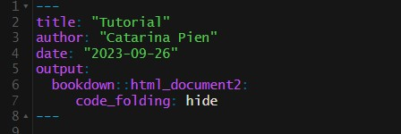

YAML Screenshot

## 1.2 Display

*Note*: The “Visual” Tab under the toolbar allows you to see what your document is looking like, and you can edit in there, with R markdown automatically converting to code for you.

### 1.2.1 Font

- *Italics*: `_text_` or `*text*`
- **Bold**: `__text__` (two underscores) or `**text**`
- Subscripts e.g. H<sub>2</sub>O `H~2~O`

### 1.2.2 Blockquotes

Use `>`

```
> "The mission of the Bureau of Reclamation is to manage, develop, and
> protect water and related resources in an environmentally and
> economically sound manner in the interest of the American public."
>
> --- Bureau of Reclamation
```

> “The mission of the Bureau of Reclamation is to manage, develop, and protect water and related resources in an environmentally and economically sound manner in the interest of the American public.”

> — Bureau of Reclamation

### 1.2.3 Indent Text

Use `|`

```
| Here you can
|  indent and separate
|   lines
|    for fun
|   patterns
|  like
| this
```

Here you can  
indent and separate  
lines  
for fun  
patterns  
like  
this

### 1.2.4 Text in a gray block

Enclose in `` ``` `` or indent by 4 spaces

````
```
Here is a chunk of code
```
````

Result:

```
Here is a chunk of code
```

### 1.2.5 Equations

Equations  
Surround with `$`

```
$a^2 + b^2 = c^2$
```

$a^2 + b^2 = c^2$.

Alternatively for a more complicated equation:

```
\begin{equation}
  f\left(k\right) = \binom{n}{k} p^k\left(1-p\right)^{n-k}
  (\#eq:binom)
\end{equation}
```

(The #eq:binom can be used to reference this equation later)

$$\begin{equation}
f\left(k\right) = \binom{n}{k} p^k\left(1-p\right)^{n-k}
\tag{1.1}
\end{equation}$$

## 1.3 Organization

### 1.3.1 Headers:

`# Header 1 (Largest)`  
`## Header 2`  
`### Header 3`

### Header with no numbering:

`### Header {-}`

### 1.3.2 Lists:

#### 1.3.2.1 Use `*`, `-`, or `+`

```
* peas
* apples
* carrots
  * baby
  * large
    * colored
    * orange
```

- peas
- apples
- carrots
  - baby
  - large
    - colored
    - orange

#### 1.3.2.2 Use numbers:

```
1. Enter data
2. QAQC
3. Publish Data
```

1. Enter data
2. QAQC
3. Publish Data

### 1.3.3 Tabs

Use `{.tabset}` and header levels. Sub-headers (exactly one level down) will become tabs.  
`### Header {.tabset}`  
`#### Plots`  
`code relevant to plots` `#### Tables`  
`code relevant to tables`

#### 1.3.3.1 Plots

```r
head(cars)
```

```
##   speed dist
## 1     4    2
## 2     4   10
## 3     7    4
## 4     7   22
## 5     8   16
## 6     9   10
```

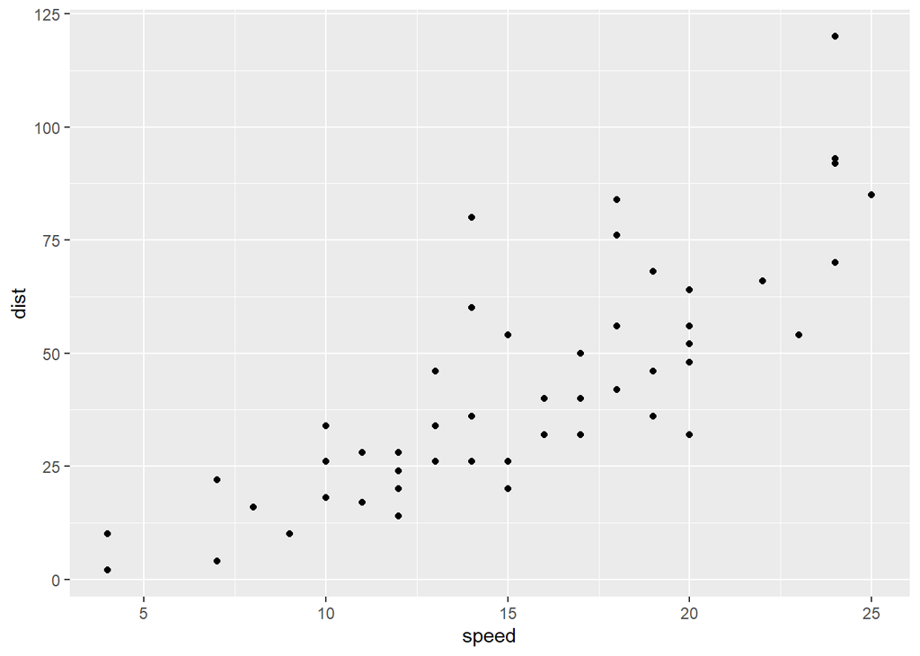

```r
ggplot(cars) + geom_point(aes(speed, dist))
```

```r
head(iris)
```

```
##   Sepal.Length Sepal.Width Petal.Length Petal.Width Species
## 1          5.1         3.5          1.4         0.2  setosa
## 2          4.9         3.0          1.4         0.2  setosa
## 3          4.7         3.2          1.3         0.2  setosa
## 4          4.6         3.1          1.5         0.2  setosa
## 5          5.0         3.6          1.4         0.2  setosa
## 6          5.4         3.9          1.7         0.4  setosa
```

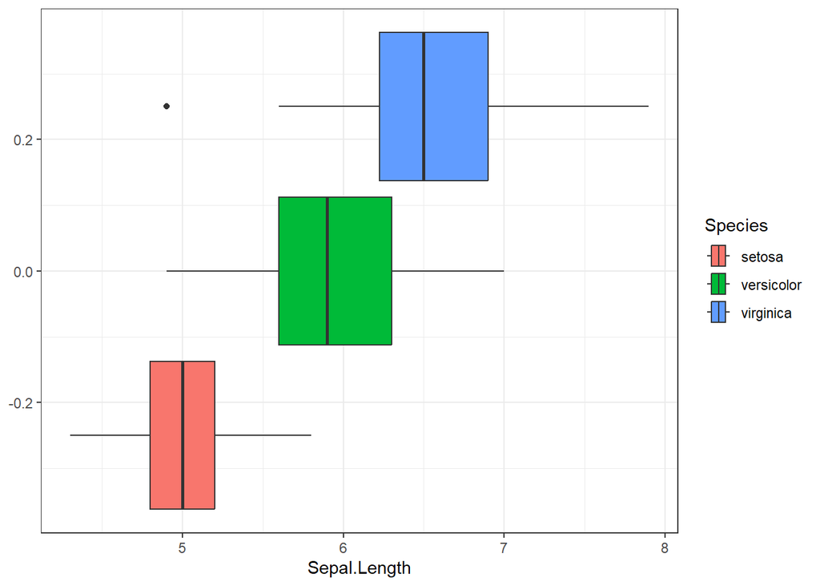

```r
ggplot(iris)  + geom_boxplot(aes(Sepal.Length, fill = Species)) +theme_bw()
```

#### 1.3.3.2 Tables

```r
knitr::kable((iris[10:20,]), "simple",  caption = "Table with sepal and petal length and width")
```

Table 1.1: Table with sepal and petal length and width

|  | Sepal.Length | Sepal.Width | Petal.Length | Petal.Width | Species |
| --- | --- | --- | --- | --- | --- |
| 10 | 4.9 | 3.1 | 1.5 | 0.1 | setosa |
| 11 | 5.4 | 3.7 | 1.5 | 0.2 | setosa |
| 12 | 4.8 | 3.4 | 1.6 | 0.2 | setosa |
| 13 | 4.8 | 3.0 | 1.4 | 0.1 | setosa |
| 14 | 4.3 | 3.0 | 1.1 | 0.1 | setosa |
| 15 | 5.8 | 4.0 | 1.2 | 0.2 | setosa |
| 16 | 5.7 | 4.4 | 1.5 | 0.4 | setosa |
| 17 | 5.4 | 3.9 | 1.3 | 0.4 | setosa |
| 18 | 5.1 | 3.5 | 1.4 | 0.3 | setosa |
| 19 | 5.7 | 3.8 | 1.7 | 0.3 | setosa |
| 20 | 5.1 | 3.8 | 1.5 | 0.3 | setosa |

```r
knitr::kable((cars[10:20,]), "simple",  caption = "Table with cars")
```

Table 1.2: Table with cars

|  | speed | dist |
| --- | --- | --- |
| 10 | 11 | 17 |
| 11 | 11 | 28 |
| 12 | 12 | 14 |
| 13 | 12 | 20 |
| 14 | 12 | 24 |
| 15 | 12 | 28 |
| 16 | 13 | 26 |
| 17 | 13 | 34 |
| 18 | 13 | 34 |
| 19 | 13 | 46 |
| 20 | 14 | 26 |

### 1.3.4 Code, Plotting, Captions

#### 1.3.4.1 Code

- Insert R Chunk
- Write code in chunk

[figure not shown]

Inserting R Chunk

```r
data("iris")
summary(iris)
```

```
##   Sepal.Length    Sepal.Width     Petal.Length    Petal.Width
##  Min.   :4.300   Min.   :2.000   Min.   :1.000   Min.   :0.100
##  1st Qu.:5.100   1st Qu.:2.800   1st Qu.:1.600   1st Qu.:0.300
##  Median :5.800   Median :3.000   Median :4.350   Median :1.300
##  Mean   :5.843   Mean   :3.057   Mean   :3.758   Mean   :1.199
##  3rd Qu.:6.400   3rd Qu.:3.300   3rd Qu.:5.100   3rd Qu.:1.800
##  Max.   :7.900   Max.   :4.400   Max.   :6.900   Max.   :2.500
##        Species
##  setosa    :50
##  versicolor:50
##  virginica :50
##
##
##
```

#### 1.3.4.2 Plot

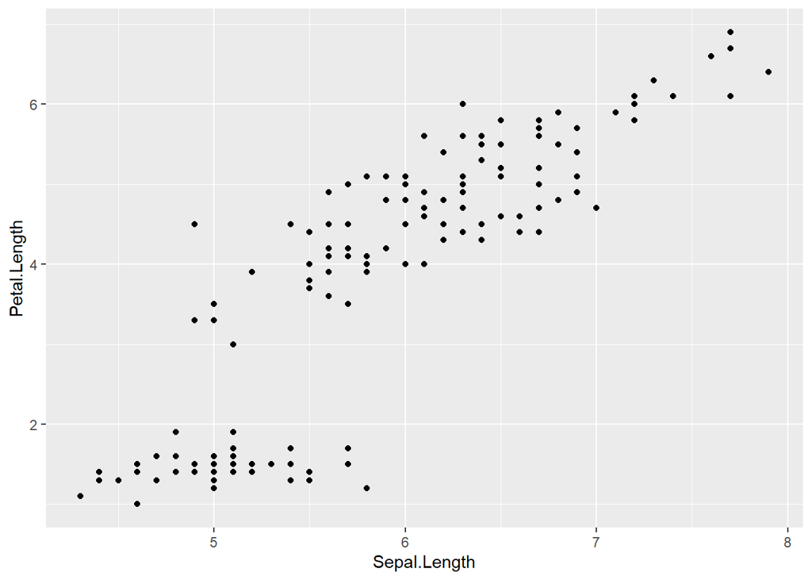

```r
library(ggplot2)
ggplot(iris, aes(x = Sepal.Length, y = Petal.Length)) + geom_point()
```

#### 1.3.4.3 Figure options

- fig.align = “center” “right” “left”
- fig.asp = ratio of width:height, height is calculated from fig.width*fig.asp
- fig.margin = TRUE (place figure in figure margin)
- fig.fullwidth = TRUE (figure is across full width)
- fig.width
- fig.height
- fig.dim = c(8,6) (width, height)
- fig.link - add a link to the figure
- fig.cap = figure caption
- out.width, out.height - specify output size
  - out.width = “50%” (can then include two figures side by side)
  - out.width = 8
- out.extra - miscellaneous
  - out.extra = ‘angle=90’
- dpi = 300 (fixes resolution)